# An Analysis of Clinical Variables and Gene Expression Data across Biopsies from Patients with Lung Adenocarcinomata

Cedric, Hannah, Merlin

2026-05-24

# Loading and Cleaning of Annotation and Expression Data

We want to clean up our annotation file. To do this we must first take a look at the file.

We can see here, that there are indeed values missing in a lot of the columns. We can also see, that the first three segments = or the first 12 digits = of the barcode encode the patient ID. We thus replace paper_patient with the barcode trimmed to position 12.

Since we only want the barcode and paper columns, we discard anything not matching to that selection. This leaves us with 20 paper columns.

As this also makes the ‘paper_’ prefix superfluous we strip it from the paper columns. Furthermore, we noticed textual NAs, which were entered into the data set as ‘[unknown]’, ‘[not available]’ and ‘[Not Available]’. We thus strip these and replace them by real NAs. We perform the same operation on the expression data, whilst we’re at it. The paper_Tumor.stage column encodes the Ajcc pathological stage. Thus, we replaced it with the ajcc staging.

When looking at the counts of NAs, the expression data are complete, whilst the annotation data have 5623 NAs in total distributed relatively evenly across all columns, with patient and Tumor.stage being the exceptions.

We know from the documentation of the data (https://gdc.cancer.gov/resources-tcga-users/tcga-code-tables/sample-type-codes), that the leading numbers of the fourth segment tell us whether the sample is a tumour or not. We use this to encode a new column entitled ‘is.tumour’ storing that information. Since this segment only has the values of ‘01’ and ‘11’, and since ‘11’ codes for healthy tissue and ‘01’ for tumour tissue, a boolean suffices.

With our annotation data (and incidentally also expression data) cleaned up and usable, we move on to the next step.

# Data Exploration

## Clinical Annotation

Pathologic stages 1A and 1B are the most common among the patients.

Patients are between 41 and 85 years old, with a mean age of 65.5 years.

There are 110 female and 73 male patients.

Most of the patients have been smokers or are smokers, only a small proportion (14%) are life long non-smokers.

EML4-ALK and CLTC-ROS1 are are the most common fusions, CLTC-ROS1 is present in the prox.-inflam expression subtype and EML4-ALK is present in the TRU subtype

Most high CIMp methylation signature samples are in Cluster Group 3 and 4, in Cluster Group 1 are only low CIMP methylation samples.

cross tabulation of iCluster Group with Sex shows that the male and female patient samples are not equally grouped, the biggest subgroup is female patients with iClusterGroup 5

cross tabulation of iCluster Group with Age shows no clear association

## Expression Data

We first aim to assess the normality of the gene expression data. As we have 3000 different genes, analysing a histogram or QQ-plot for each one is not feasible. Instead we perform Shapiro-Wilks tests for each gene across the 455 samples. We can then plot a histogram of p-values to roughly ascertain the normality across different genes and we can calculate that only ~82% of genes gave a p-value lower than 0.05.

For better insight we select some genes with high and some with low p-values and make QQ-plots on these.

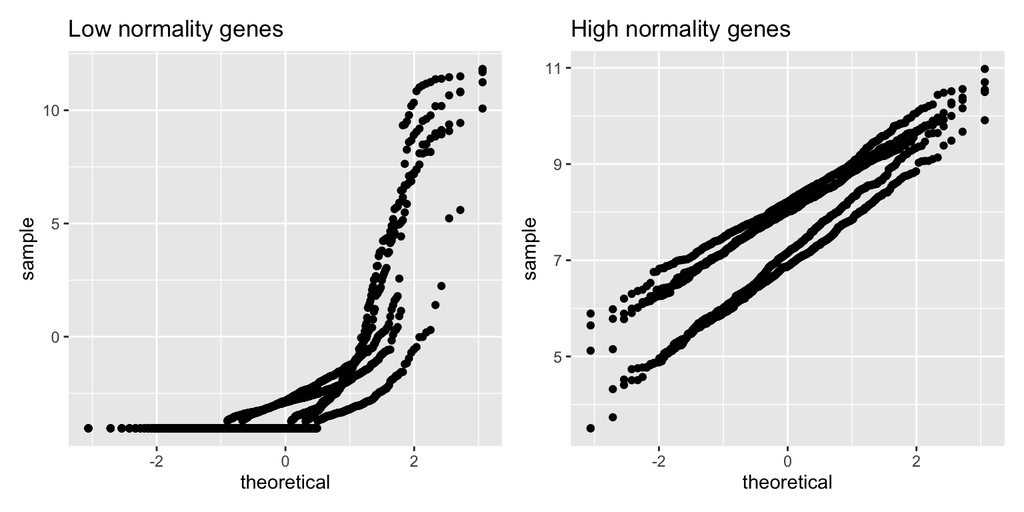

Next, we perform quantile normalisation of the gene expression data. The Shapiro-Wilks test now yields only ~77% of genes with a p-value lower than 0.05.

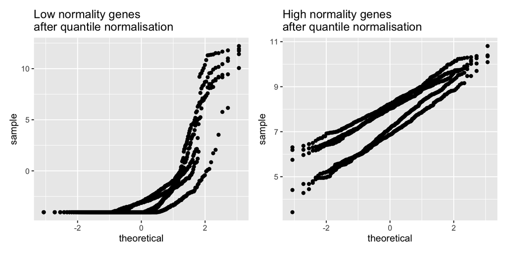

# Data Analysis

## Dimensionality Reduction of Annotation Data

Principal component analysis was applied to visualize potential clustering patterns and relationships in the high-dimensional dataset. We first saw, that the tumor samples are clustered together and away from the normal samples.

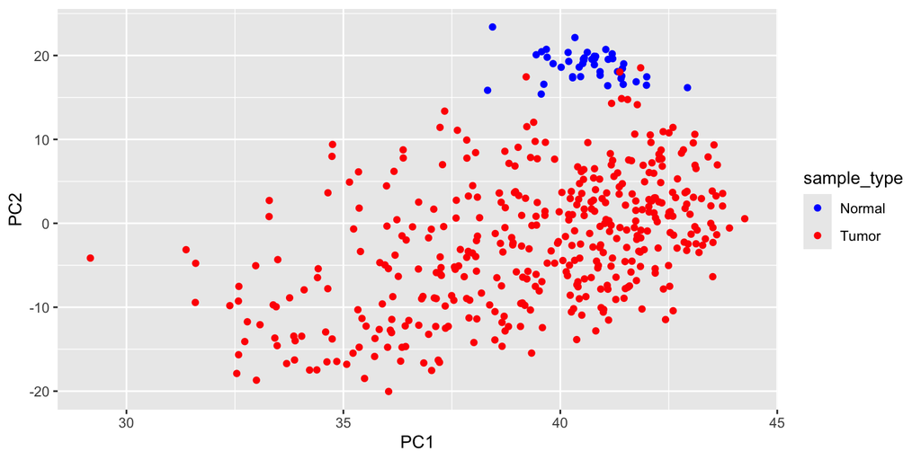

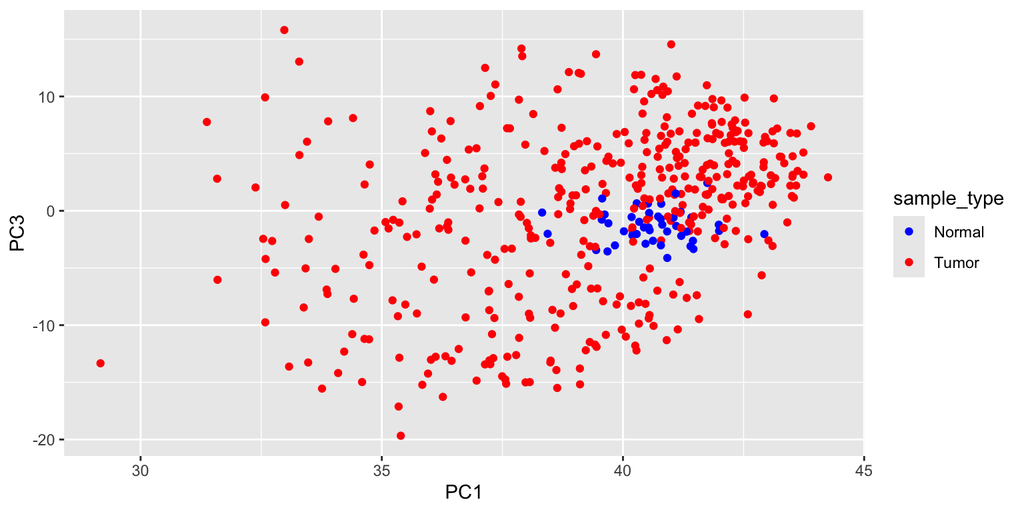

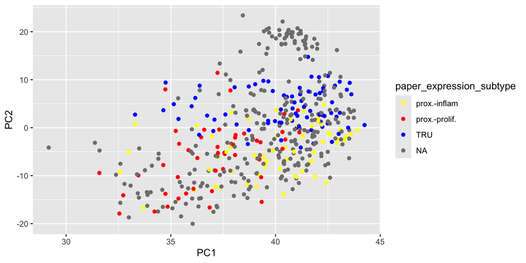

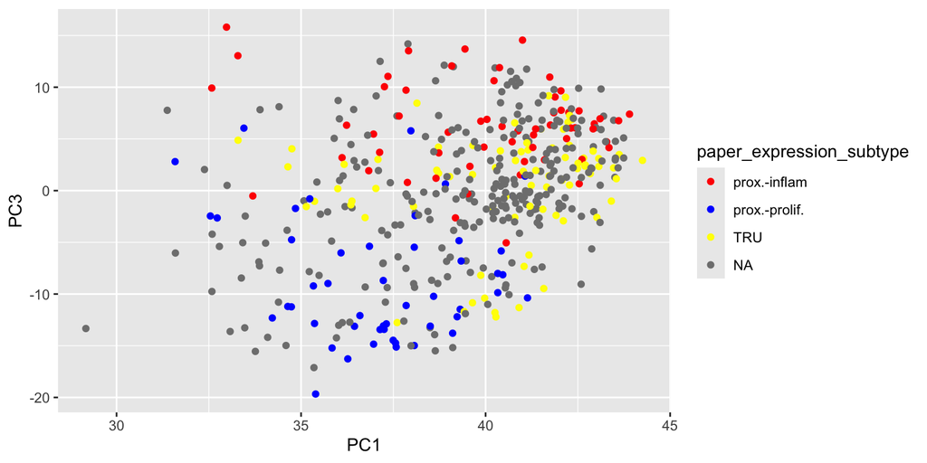

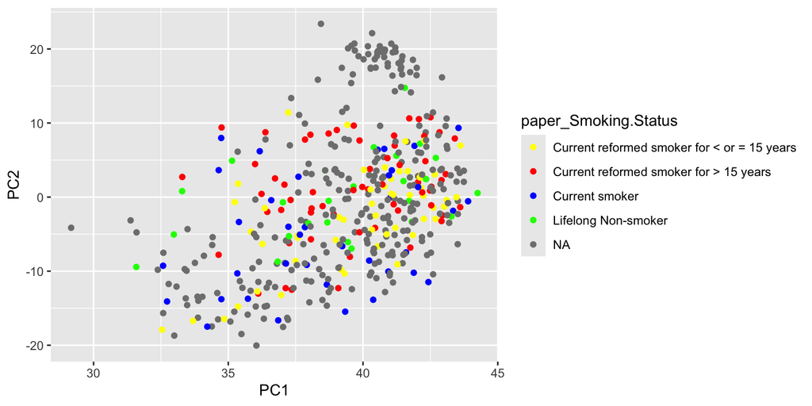

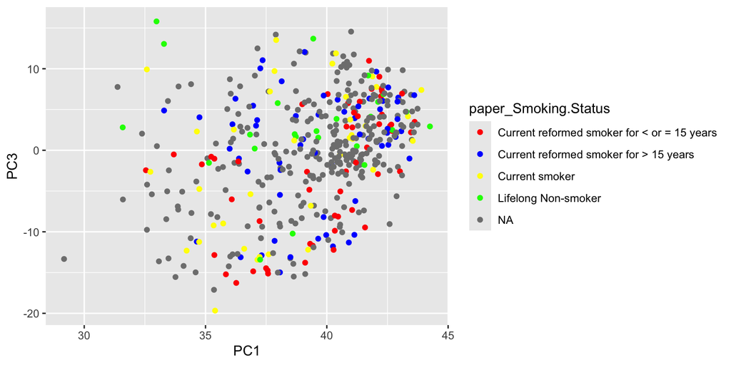

Smoking status types are not separated in the Principal component analysis. Since PCA isn’t separating the feature expression subtypes clearly, we perform t-distributed Stochastic Neighbor Embedding for further visualisation.The resulting projection showed that samples of the same subtype tended to cluster together, but not entirly distinct.

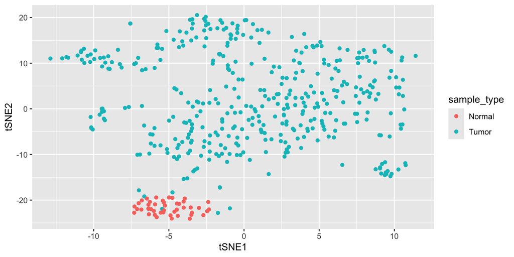

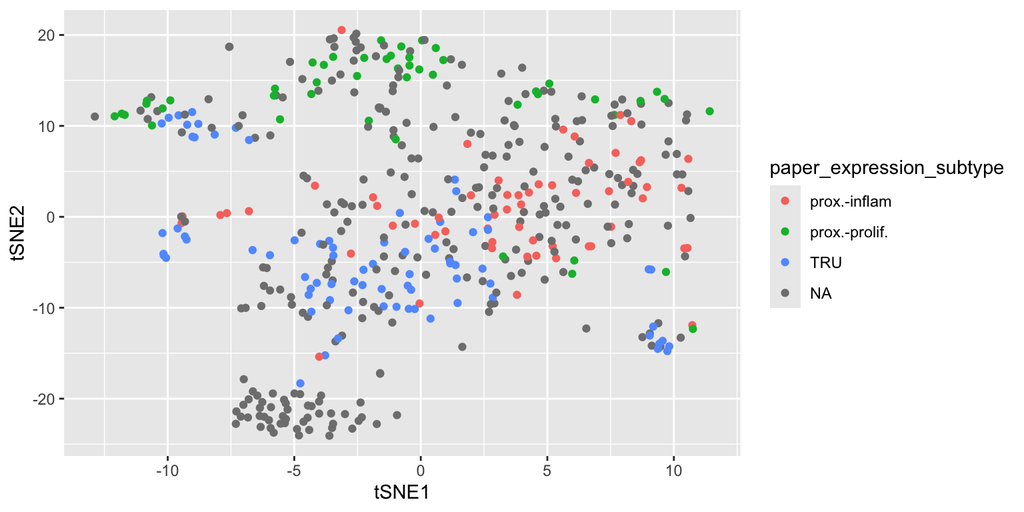

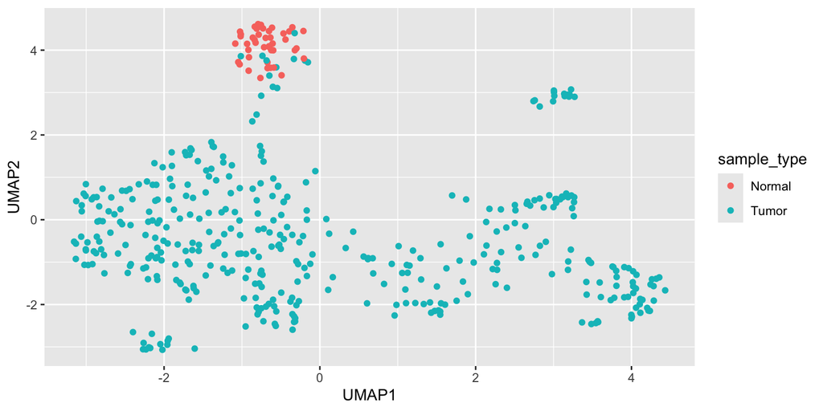

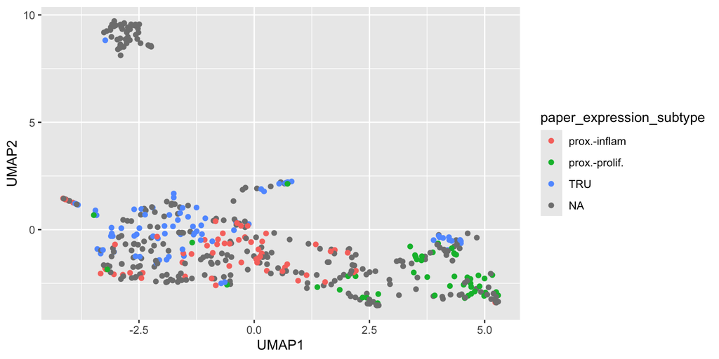

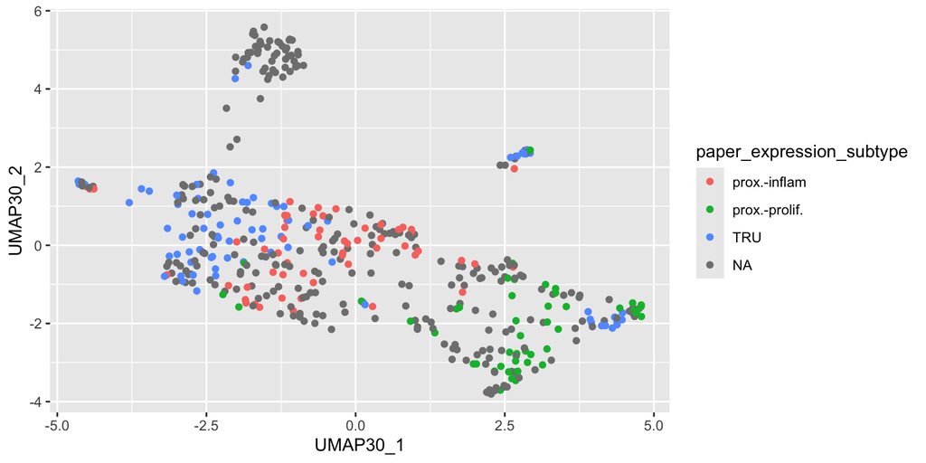

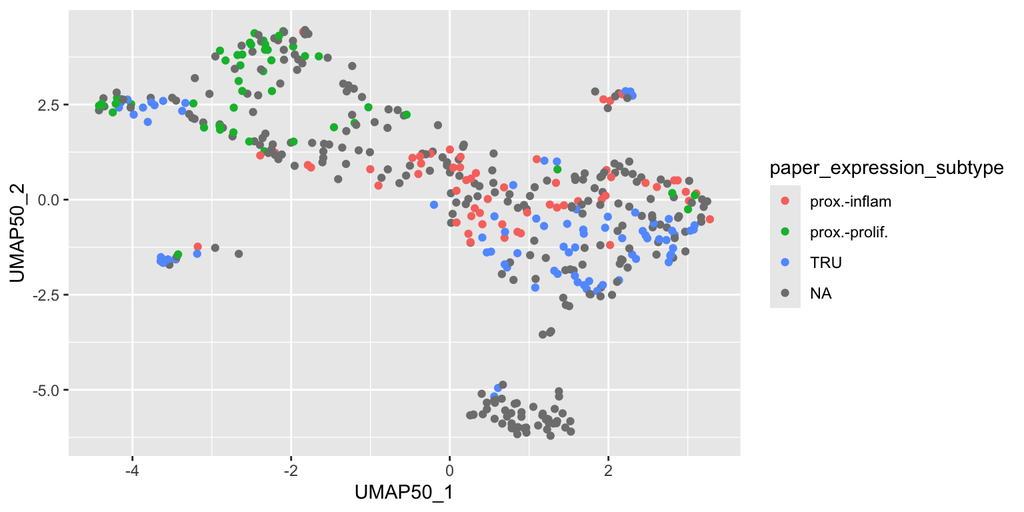

Using only the top 10 principal components resulted in more clearly separated and compact clusters, whereas including a larger number of principal components introduced additional noise and reduced cluster separation in the UMAP projection.

## Differential Expression Analysis

We now set out to perform differential expression analysis between the different tumour subtypes. After Benjamini-Hochberg correction, we visualise the Top 50 most significant differentially expressed genes in a heatmap.

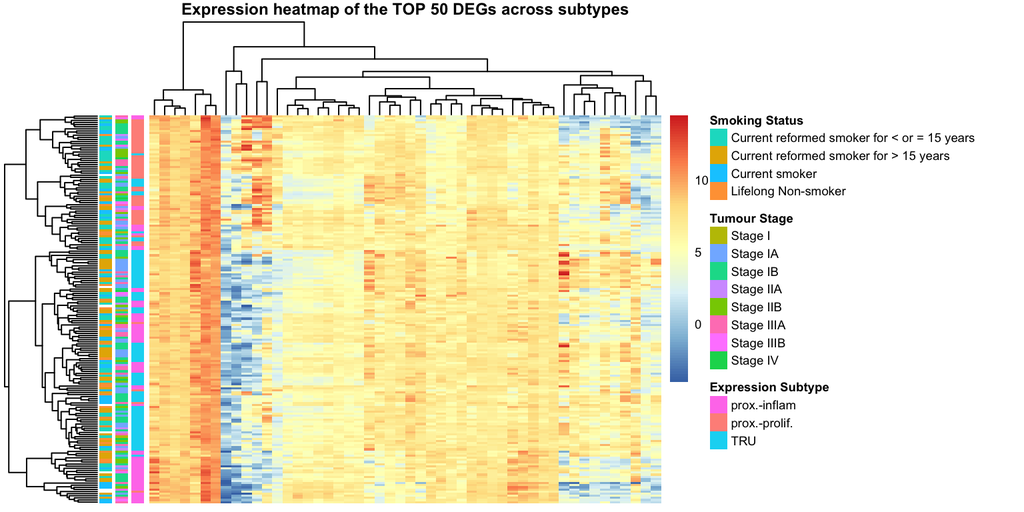

We then compare the top 5 DEGs using a boxplot. TRU seems to be the more clearly differentiated subtype compared to prox.-inflam. and prox.-prolif.. Most of the genes are well known in tumour research, namely KPNA2, NFIX, RASGRF1 and, TPX2. ADH1B is less strongly associated with tumours, yet some finding do link it to reduced tumour stemness.

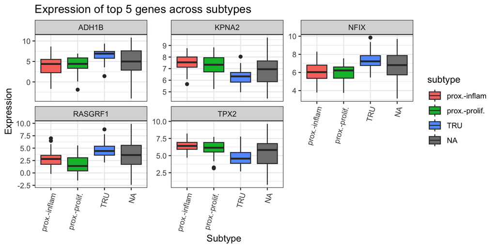

## Expression Correlation amongst Highly Differentially Expressed Genes

We can also compare the correlation between top DEGs to find co-expressed or anti-expressed modules. There seems to be some genes which are in co-expressed and a separate module which seems inversely correlated.

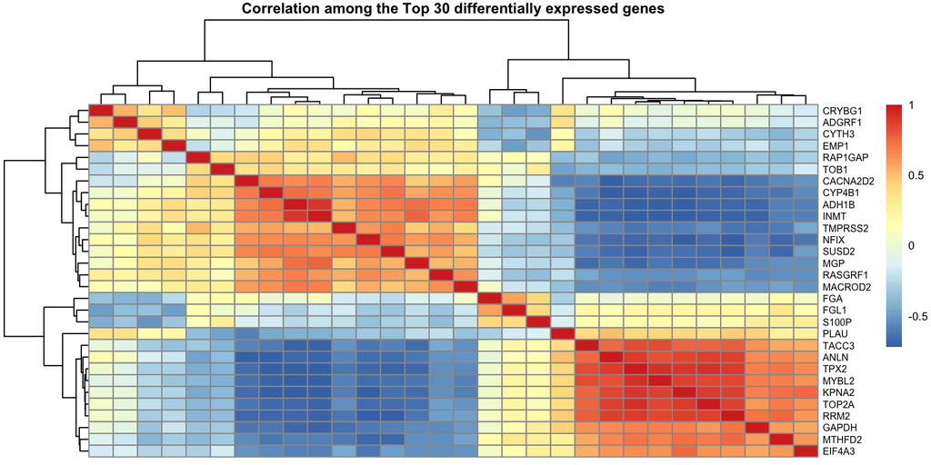

Furthermore, we want to compare the top 30 DEGs to clinical feature. For this, we compute the correlation between continous clincial variables and the top 30 DEGs.

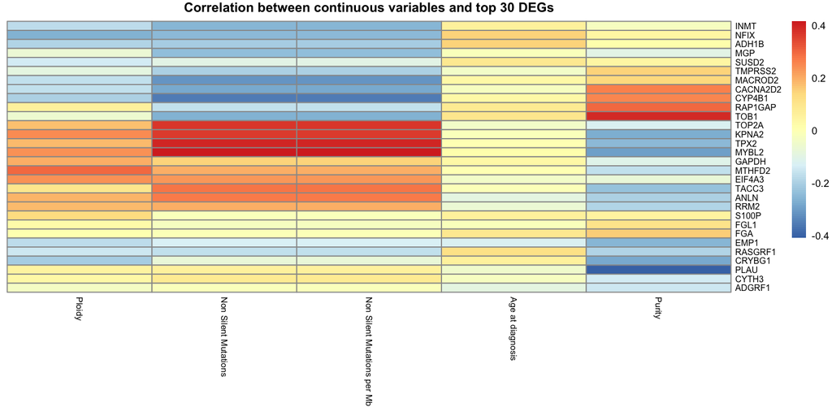

Finally, with respect to the differential gene expression, we want to ascertain how top 30 DEG expression differs between tumour stages. Curiously, many of the top DEGs are differentially expressed only in Stage IA vs. rest

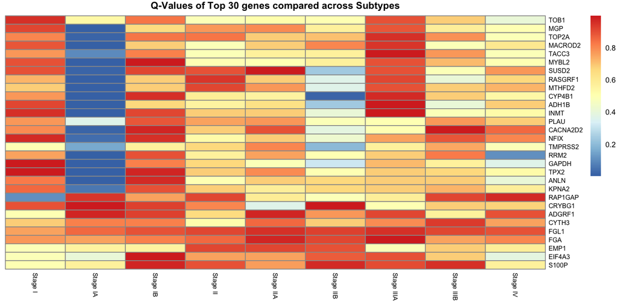

# Predictive Modelling

## Based on Expression Data

### Target: Expression Subtype

First we initialise a mutable combined data set from our immutable annot and exp data sets, discard unnecessary annotation columns, and split the data into a training and testing data set. We also scale and centre both data sets based on the training data.

Using the scaled and centred training data, we then train random forest and multinomial logistical regression models and make a prediction each.

We want to take a look at the 5 most important variables for both models. For the random forest regression, we simply use variable importance as the metric. For multinomial logistical regression, we use the euclidean deviance of the coefficients from zero for each gene. These differ.

We then walk through both lists of genes sorted by their importance to the models until we reach an overlaping selection of 5. The given depth shows us how many of the sorted list we need to include to get our overlap.

```
## $important.variables
## [1] "FGA"     "ERN2"    "SCGB3A2" "KIF1A"   "MSMB"
##
## $depth
## [1] 16
```

### Target: Tumor Stage

We now do the exact same for the prediction of tumor stage, with the addition of splitting the tumor stages into only two categories: Early and Late.

If we look at the importance of the various genes to the prediction, we again see some overlap between the random forest and binomial logistical regressions in the top 5 most important variables.

We thus again look at how far we need to go to find an overlap between all three models of 5 important variables.

```
## $important.variables
## [1] "FGA"     "AQP5"    "AKR1B10" "MUC5AC"  "GPX2"
##
## $depth
## [1] 11
```

## Quality and Comparison of Models

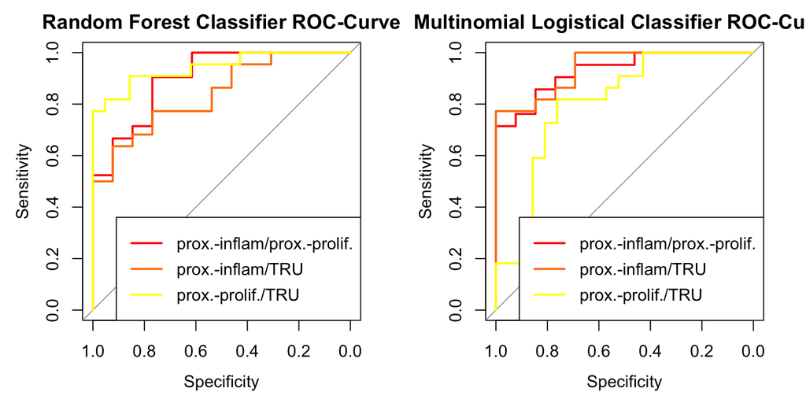

We now take a look at the ROC curves for the tumour stage classifiers. We see that all classifiers are basically useless, though on other seeds, random forest classification and kNN outstripped logistical regression.

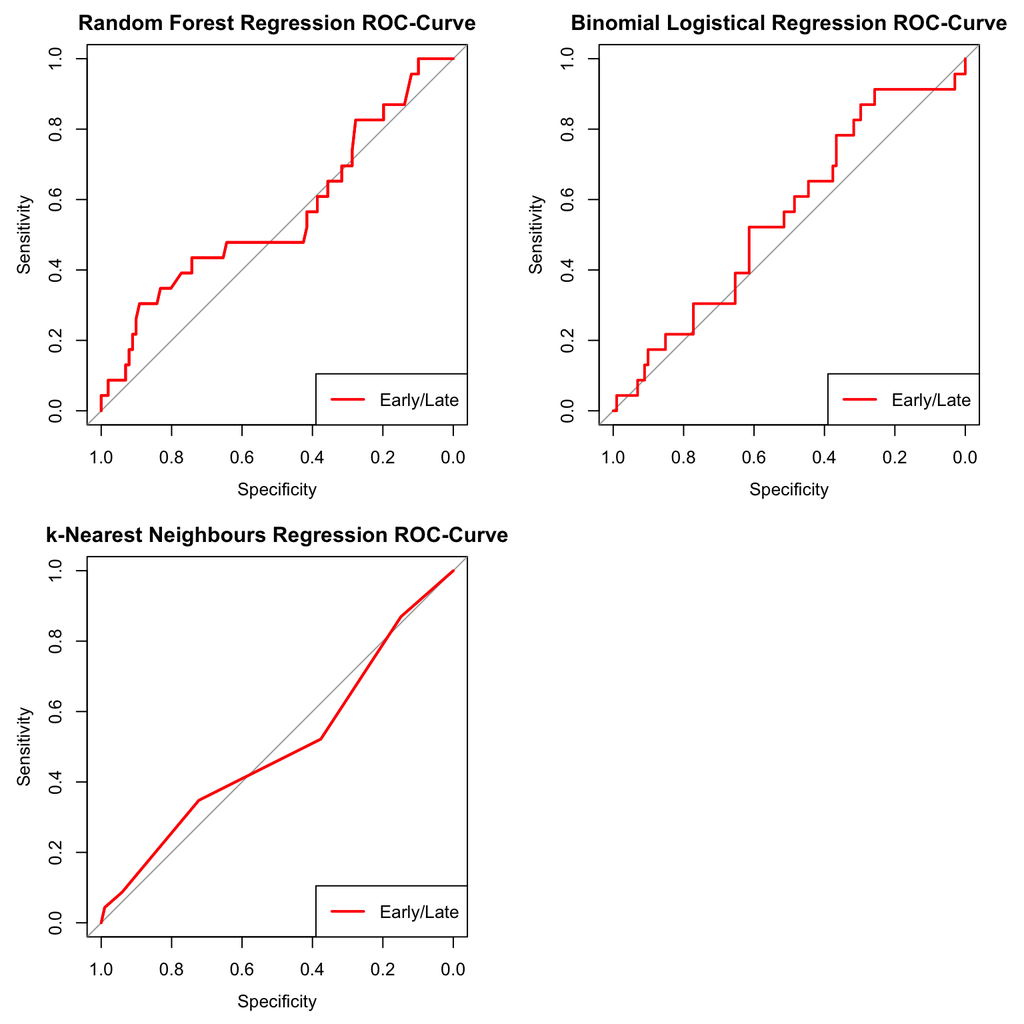

When we look at key values for these classifiers (first table expression subtype classification, second table tumour stage classification) we can see why some of them don’t perform well. The performance of the expression type classifiers are incredibly sensitive to seed changes. They are unstable and exceedingly subpar. In different runs random forest had a far better accuracy of approximately 0.8.

|  | Random.Forest | Multinomial.Logistical |
| --- | --- | --- |
| Accuracy | 0.6250000 | 0.6607143 |
| Macro-Averaged F1 | 0.6175156 | 0.6601431 |
| Precision for Class: prox.-inflam | 0.5000000 | 0.5789474 |
| Precision for Class: prox.-prolif. | 0.7500000 | 0.7333333 |
| Precision for Class: TRU | 0.6250000 | 0.6818182 |
| Recall for Class: prox.-inflam | 0.6153846 | 0.8461538 |
| Recall for Class: prox.-prolif. | 0.5714286 | 0.5238095 |
| Recall for Class: TRU | 0.6818182 | 0.6818182 |

|  | Random.Forest | Binomal.Logistical | k.Nearest.Neighbours |
| --- | --- | --- | --- |
| Accuracy | 0.8145161 | 0.8064516 | 0.8145161 |
| F1 | 0.8977778 | 0.8918919 | 0.8968610 |
| Precision | 0.8145161 | 0.8181818 | 0.8196721 |
| Recall | 1.0000000 | 0.9801980 | 0.9900990 |

In the prediction of tumour stage, we have the problem, that our samples at Early stage far outnumber those at Late stage.

```
##  Accuracy        F1 Precision    Recall
## 0.5967742 0.7126437 0.8493151 0.6138614
```

Also the ROC Curve looks healthier in this seed.

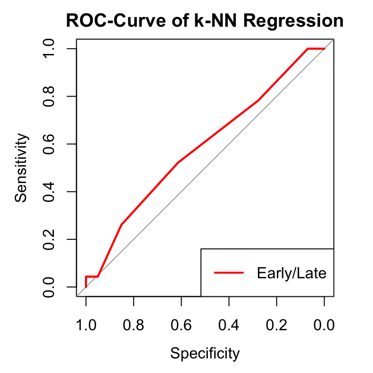

We determined the top 5 genes for the classifiers for each of the classification problems (expression subtype, tumour stage) by looking at the best-performer and by integrating across classifiers to find an overlap of top-5 important genes. We can here see, that the top-5 differentially expressed genes have no overlap with the most important predictors.

```
## [1] FALSE FALSE FALSE FALSE FALSE
## [1] FALSE FALSE FALSE FALSE FALSE
## [1] FALSE FALSE FALSE FALSE FALSE
## [1] FALSE FALSE FALSE FALSE FALSE
```

This is somewhat surprising, but may be due to the DEGs being found by 1-vs-rest comparison and the classifiers lumping all samples of a expression subtype or tumour stage together. Furthermore, we may find overlap, when looking at genes less important to the classifiers. We do so for one example.

```
## $important.variables
## [1] "FGL1"    "AKR1C2"  "SCGB3A1" "S100P"   "FGA"
##
## $depth
## [1] 43
```

To find an overlap, we need to go to a depth of 43, which is fascinating, but probably due DEGs being determined by difference in 1 group vs the rest, whereas the classifiers use simple the top 50 genes with the highest variance, irrespective of group. We sadly don’t have page space to show a rerun of the classifiers for expression subtype.

All of these have significance to cancers. Depending on their regulation, they can modulate cancer cell proliferation, survival, and aggressiveness.

## Based on Clinical Annotation

We calculate a multinomal logistic regression (was too complex with all features so we chose 3: Age at diagnosis, Tumor.stage, Smoking.status) We tried different combinations of features to get the best possible model. The model with these 3 features makes the most sense to predict expression_subtype (model has the highest accuracy)

|  | . |
| --- | --- |
| Accuracy | 0.5319149 |
| Macro-Averaged F1 | 0.4736842 |
| Precision for Class: PI | 0.4444444 |
| Precision for Class: PP | 0.5714286 |
| Precision for Class: TRU | 0.5483871 |
| Recall for Class: PI | 0.2666667 |
| Recall for Class: PP | 0.3333333 |
| Recall for Class: TRU | 0.8500000 |

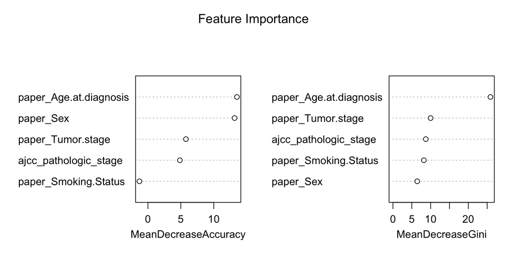

|  | . |
| --- | --- |
| Accuracy | 0.4255319 |
| Macro-Averaged F1 | 0.3977553 |
| Precision for Class: PI | 0.3333333 |
| Precision for Class: PP | 0.4000000 |
| Precision for Class: TRU | 0.4800000 |
| Recall for Class: PI | 0.2666667 |
| Recall for Class: PP | 0.3333333 |
| Recall for Class: TRU | 0.6000000 |

|  | . |
| --- | --- |
| Accuracy | 0.4893617 |
| Macro-Averaged F1 | 0.3985632 |
| Precision for Class: PI | 0.4000000 |
| Precision for Class: PP | 0.7500000 |
| Precision for Class: TRU | 0.4736842 |
| Recall for Class: PI | 0.1333333 |
| Recall for Class: PP | 0.2500000 |
| Recall for Class: TRU | 0.9000000 |

```
## Multi-class area under the curve: 0.607
```

```
## Multi-class area under the curve: 0.7639
```

```
## Multi-class area under the curve: 0.5
```

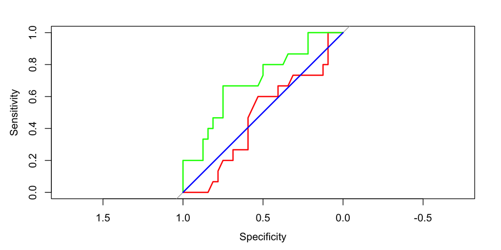

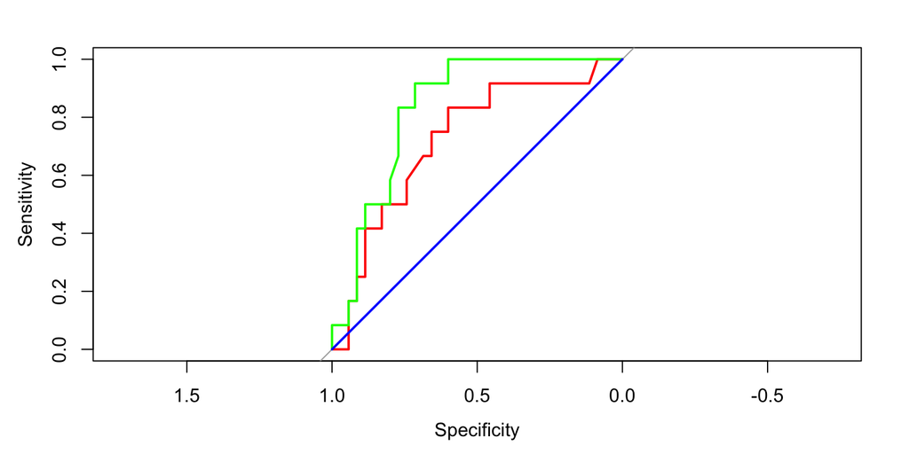

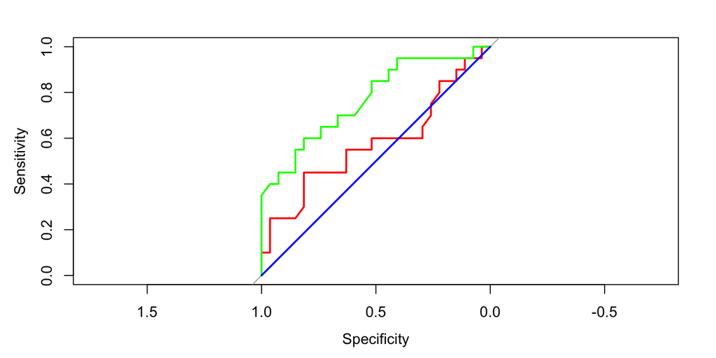

The knn model showed poor predictive performance with an AUC of 0.5, which means that the prediction it makes is not better than guessing by chance. We know that k nearest neighbor is a distance based model, that’s why it is not performing well with categorical variables. We tried to encode dummy variables, to have numerical values but it didn’t work.

## Integrative Classifier

We now build a integrative classifier, using the top-25 most important genes for our random forest classifier targeting expression subtype as well as the clinical variables “expression_subtype”, “Tumor.stage”, “Nonsilent.Mutations”, “Ploidy.ABSOLUTE.calls”,“Purity.ABSOLUTE.calls”, “Smoking.Status”, and “Age.at.diagnosis”. As can be seen from the two ROC graphs and the comparison table of key characteristics, this does improve the model. The quality of both models depends heavily on seed and both classifiers are highly unstable and relatively poor. Observation count is probably simply too small.

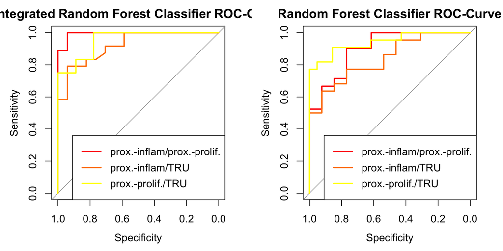

|  | Integrated.Random.Forest | Non.integrated.Random.Forest |
| --- | --- | --- |
| Accuracy | 0.8000000 | 0.6250000 |
| Macro-Averaged F1 | 0.7975368 | 0.6175156 |
| Precision for Class: prox.-inflam | 0.7619048 | 0.5000000 |
| Precision for Class: prox.-prolif. | 0.7777778 | 0.7500000 |
| Precision for Class: TRU | 0.8500000 | 0.6250000 |
| Recall for Class: prox.-inflam | 0.9411765 | 0.6153846 |
| Recall for Class: prox.-prolif. | 0.7777778 | 0.5714286 |
| Recall for Class: TRU | 0.7083333 | 0.6818182 |

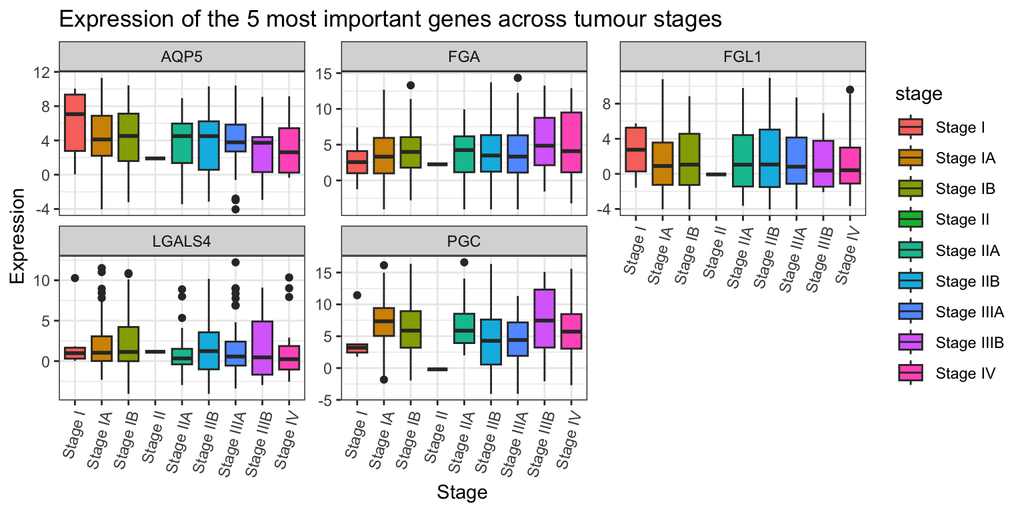

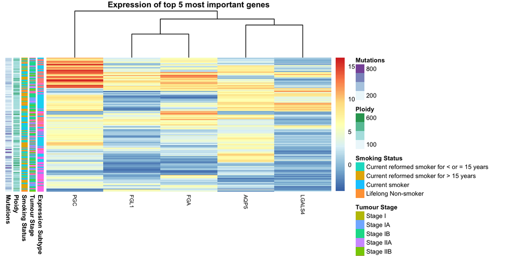

# Discussion

The given data set is extremely poor and missing a lot of annotation, which significantly lowers their value and the predictive capacity of classifiers trained off them. Most classifiers are poor, whether using expression data or clinical annotation, and all are sensitive to seed changes. The data set contains too few usable observations, as to initialise any well-functioning classifier.

Those genes we found to be predictive (in whatever low capacity that was) are sensible, as they are known to have functions in other cancers and may indeed be able to differentiate various forms of lung adenocarcinomata from one another.

The differentially expressed genes between the subtypes were mostly those, which differed from TRU, to proximal-inflamatory, and proximal-proliferative. This indicates, that TRU might be a more distinct subtype, compared to proximal-inflamatroy, and proximal-proliferative, which may be more closely related.

Correlating the top 30 genes across all samples, both tumour and healthy tissue, revealed two main co-expressed modules which were inversely correlated with one another. One of these module contained a plethora of genes which are known to be downregulated in lung cancers. The second module, which was inversely correlated with the first, instead contained genes which are tendentially upregulated in lung cancers.

As we used the full set of observations, including healthy tissue samples, this might reflect the genetic changes of cancer cells. We posit that this is due the casette of tumour supressor genes being downregulated in tumour tissue and upregulated in healthy tissue, whilst the inverse is true for the casette of tumour associated genes.

# References

Akasha R, Enrera JA, Fatima SB, et al. Oxidative phosphorylation and breast cancer progression: insights into PGC-1α’s role in mitochondrial function. Naunyn-Schmiedeberg’s Archives of Pharmacology 2025;398:9887–900. doi:10.1007/s00210-025-04018-w

Gao P, Chen A, Tian H, et al. Investigating the mechanism and the effect of aquaporin 5 (AQP5) on the self-renewal capacity of gastric cancer stem cells. J Cancer 2024;15:4313–27. doi:10.7150/jca.92745

Han X, Liu Z, Cui M, et al. FGA influences invasion and metastasis of hepatocellular carcinoma through the PI3K/AKT pathway. Aging 2024;16:12806–19. doi:10.18632/aging.206011

Li S, Yang K, Ye J, et al. LGALS4 inhibits glycolysis and promotes apoptosis of colorectal cancer cells via β‑catenin signaling. Oncol Lett 2025;29:126. doi:10.3892/ol.2025.14873

Schafer ZT, Brugge JS. IL-6 involvement in epithelial cancers. J Clin Invest 2007;117:3660–3. doi:10.1172/JCI34237

Xu X, Zhang B, Chen G, et al. Nanoengineered T cell membrane-coated nanodecoys blocking LAG-3/FGL1 to enhance cancer immunotherapy. Biomaterials 2026;326:123695. doi:10.1016/j.biomaterials.2025.123695

Yang X, Zhou C, Kong W, et al. Relationship between AQP5 and chemotherapy resistance in colorectal cancer cells and its mechanism. Discov Oncol 2025;16:1468. doi:10.1007/s12672-025-03193-9